# Loan Data from Prosper Exploration

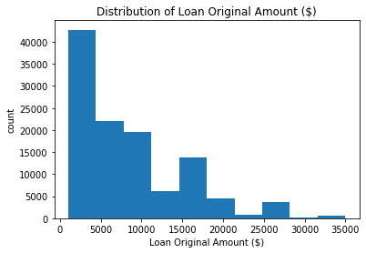

```python
# Why am I not using a standard scaled plot?
# The LoanOriginalAmount variable has a long tail. A lot of loans had small size (< $10k) and few on the higher end.
# If I use a standard scaled plot, the graph will look like below, which does not give me any of the valuable insights I mentioned above.
plt.hist(data = loan_copy, x = 'LoanOriginalAmount')
plt.xlabel('Loan Original Amount ($)')
plt.ylabel('count')
plt.title('Distribution of Loan Original Amount ($)');
```

**Observations**:

- Other, Professional, and Computer Programmer appeared the most often in the dataset.
- Because "Other" and "Professional" tend to be a bit general, we want to conclude that Computer Programmer, Executive, and Teacher tend to appear most frequently when it comes to taking out loans.
- In comparison, on the right side of the graph, we are seeing that students and judge were not likely to take out loans, which makes sense because students usually don't need to worry about home improvements or business expenses.

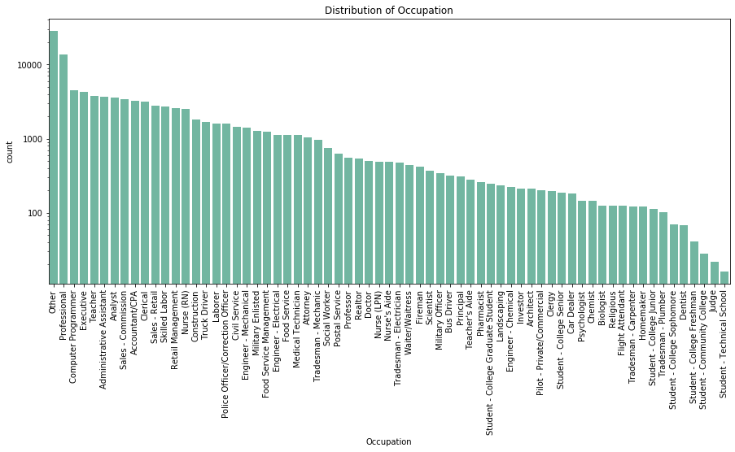

```python
# Time to plot which occupations tend to appear the most often / least often in the dataset.
occupation_order = loan_copy['Occupation'].value_counts().index
plt.figure(figsize = [15,6])
sb.countplot(data = loan_copy, x = 'Occupation', color = base_color, order = occupation_order)
plt.xticks(rotation = 90);
plt.yscale('log')
plt.ylabel('count')
y_ticks = [1e2, 1e3, 1e4]
y_ticks_names = ['100','1000','10000']
plt.yticks(y_ticks, y_ticks_names)
plt.title('Distribution of Occupation');
plt.show()
```

```python
# I also would like to investigate why do people take out loans. What's the money for?
# By examining the Listing Category variable, I noticed that it is in numbers and hard to decipher, so I decided to
# convert listing Category to clear and self-explanatory ones.
loan_copy['ListingCategory (numeric)'] = loan_copy['ListingCategory (numeric)'].astype(str)
listing_details = {
    '0':'Not Available',
    '1':'Debt Consolidation',
    '2':'Home Improvement',
    '3':'Business',
    '4':'Personal Loan',
    '5':'Student Use',
    '6':'Auto',
    '7':'Other',
    '8':'Baby & Adoption',
    '9':'Boat',
    '10':'Cosmetic Procedure',
    '11':'Engagement Ring',
    '12':'Green Loans',
    '13':'Household Expenses',
    '14':'Large Purchases',
    '15':'Medical/Dental',
    '16':'Motorcycle',
    '17': 'RV',
    '18':'Taxes',
    '19': 'Vacation',
    '20': 'Wedding Loans'
    }

# Function to apply
def abbreviate_source(loan_copy):
    if loan_copy['ListingCategory (numeric)'] in listing_details.keys():
        abbrev = listing_details[loan_copy['ListingCategory (numeric)']]
        return abbrev
    else:
        return loan_copy['ListingCategory (numeric)']

loan_copy['ListingCategory (numeric)'] = loan_copy.apply(abbreviate_source, axis=1)
```

```python
# Check if my code did the magic.
loan_copy['ListingCategory (numeric)'].value_counts()
```

```
Debt Consolidation    58308
Not Available         16965
Other                 10494
Home Improvement       7433
Business               7189
Auto                   2572
Personal Loan          2395
Household Expenses     1996
Medical/Dental         1522
Taxes                   885
Large Purchases         876
Wedding Loans           771
Vacation                768
Student Use             756
Motorcycle              304
Engagement Ring         217
Baby & Adoption         199
Cosmetic Procedure       91
Boat                     85
Green Loans              59
RV                       52
Name: ListingCategory (numeric), dtype: int64
```

**Observations**:

- Debt consolidation won by an overwhelming amount as we are seeing over 50% of the loans were for debt consolidation in this dataset.
- The least popular listing category was RV, Green Loans, and Boats, which makes sense as these usage is more niche than the other categories.

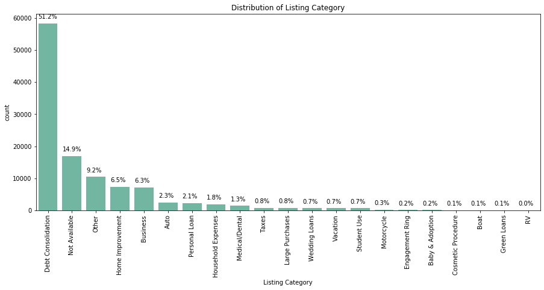

```python
# plotting loan status to get an idea of this categorical vairable's distribution
listing_counts = loan_copy['ListingCategory (numeric)'].value_counts()
listing_order = loan_copy['ListingCategory (numeric)'].value_counts().index
plt.figure(figsize = [15,6])
sb.countplot(data = loan_copy, x = 'ListingCategory (numeric)', color = base_color, order = listing_order)
plt.xticks(rotation = 90);
plt.ylabel('count')
plt.xlabel('Listing Category')
plt.title('Distribution of Listing Category');
for i in range(listing_counts.shape[0]):
    count = listing_counts[i]
    pct_string = '{:0.1f}%'.format(100*count/n_loan)
    plt.text(i-0.4,count+2000, pct_string, va = 'center');
plt.show()
```

## Discuss the distribution(s) of your variable(s) of interest. Were there any unusual points? Did you need to perform any transformations?

Both LoanOriginalAmount and Borrower APR appear to be multimodal. I did not perform any transformations because the data looks accurate.

## Of the features you investigated, were there any unusual distributions? Did you perform any operations on the data to tidy, adjust, or change the form of the data? If so, why did you do this?

**Were there any unusual distributions?**  
No.

**Adjustments:**

When examining the Listing Category variable, I noticed that it is in number format and hard to decipher, so I decided to convert listing Category to clear and self-explanatory ones.

**Change the form**:

I created two new variables.

1. average credit score: I averaged CreditScoreRangeLower and CreditScoreRangeUpper to form a single variable.
2. Credit History Length: take the difference between DateCreditPulled and FirstRecordedCreditLine to measure this borrower's credit history length. We want to include this variable because it usually is an important factor to credit scores.

## Bivariate Exploration

To start off, I want to look at the pairwise correlation present between features in the data. First, let's take a look at the relationships between numerical variables to see if any particular pairs have strong correlations.

```python
numeric_vars = [
    'Term',
    'BorrowerAPR',
    'BorrowerRate',
    'ProsperRating (numeric)',
    'ProsperScore',
    'StatedMonthlyIncome',
    'LoanOriginalAmount',
    'CreditScoreRangeLower',
    'CreditScoreRangeUpper',
    'average_credit_score',
    'credit_length',
    'EmploymentStatusDuration',
    'CurrentCreditLines',
    'OpenCreditLines',
    'TotalCreditLinespast7years',
    'OpenRevolvingMonthlyPayment',
    'RevolvingCreditBalance',
    'AvailableBankcardCredit'
               ]
```

**Observations**:  
It becomes apparent that the following variables have a moderate correlation with Borrower APR (based on our Udacity's Practical Statistics module, an 0.3<=r<0.7 was considered a moderate correlation.

Surprisingly, variables like Employment Status Duration (r = -0.009), stated monthly income (-0.082), and credit length (-0.029) have very weak correlations with BorrowerAPR.

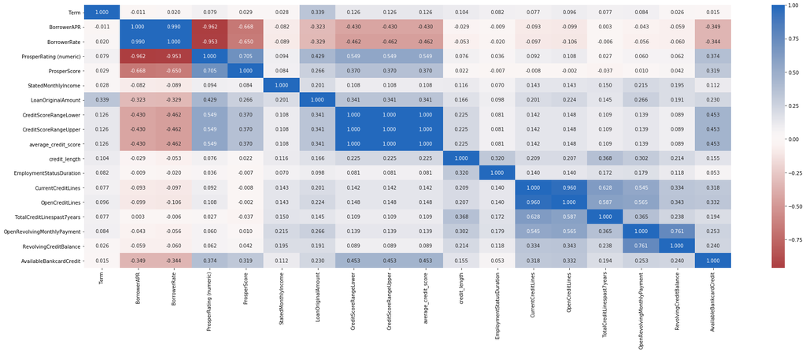

```python
# correlation plot
plt.figure(figsize = [30,10])
sb.heatmap(loan_copy[numeric_vars].corr(), annot = True, fmt = '.3f',
          cmap = 'vlag_r', center = 0)
plt.show()
```

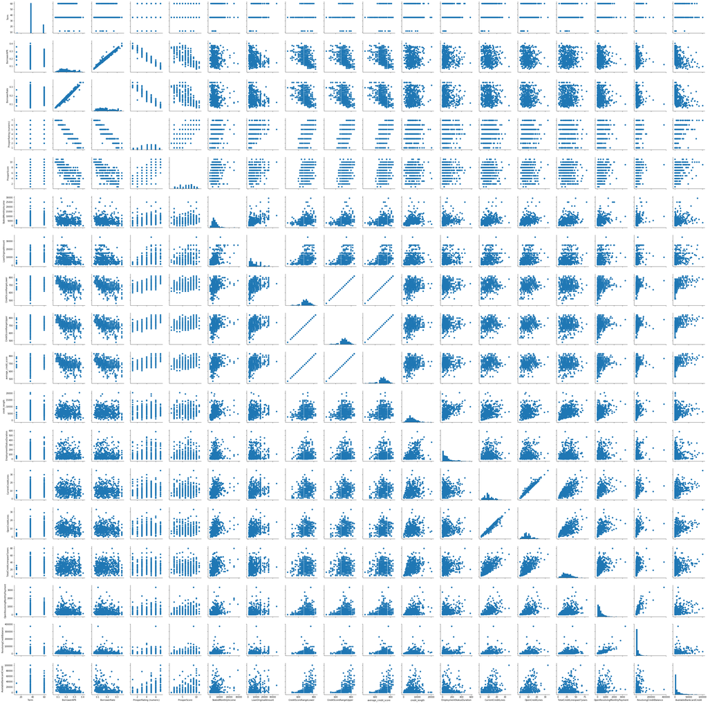

```python
# plot matrix: sample 500 loans so that plots are clearer and they render faster.
samples = np.random.choice(loan_copy.shape[0], 500, replace = False)
loan_samples = loan_copy.loc[samples,:]
g = sb.PairGrid(data = loan_samples, vars = numeric_vars)
g = g.map_diag(plt.hist, bins = 20);
g.map_offdiag(plt.scatter)
```

### Numerical vs. Numerical

#### Pair 1: ProsperRating (numeric) vs. Borrower APR

**Observations**:  
When Prosper Rating numeric increases, Borrower APR tends to decrease.

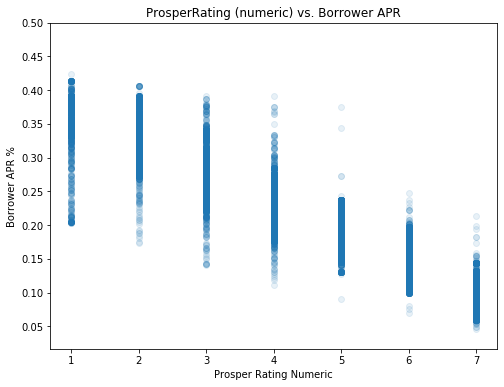

```python
# First of all, we are going to plot the relationships between ProsperRating (numeric) and Borrower APR as they had the highest correlations.
plt.figure(figsize = [8, 6])
plt.scatter(data = loan_copy, x = 'ProsperRating (numeric)', y = 'BorrowerAPR', alpha = 1/10)

x_ticks = [1,2,3,4,5,6,7]
x_tick_name = map(str, x_ticks)
plt.xticks(x_ticks,x_tick_name )
plt.xlabel('Prosper Rating Numeric')
plt.title('ProsperRating (numeric) vs. Borrower APR')

y_ticks = [0.05,0.10,0.15,0.20,0.25,0.30,0.35,0.40,0.45,0.50]
y_tick_name = ['0.05','0.10','0.15','0.20','0.25','0.30','0.35','0.40','0.45','0.50']
plt.yticks(y_ticks, y_tick_name)
plt.ylabel('Borrower APR %')

plt.show()
```

### Numerical vs. Numerical

#### Pair 2: average credit score vs. Borrower APR

**Observations**:  
Although we can vaguely see a negative relationship between the two variables, it's not loud and clear. When the graph is not clear, we can take a smaller sample.

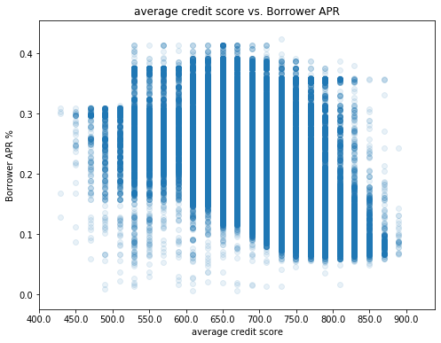

```python
# Next, I am going to plot the relationship between Borrower APR and average credit score.
plt.figure(figsize = [8, 6])
plt.scatter(data = loan_copy, x = 'average_credit_score', y = 'BorrowerAPR', alpha = 1/10)

binsize = 50
x_ticks = np.arange(400,loan_copy['average_credit_score'].max()+binsize, binsize)
plt.xlim(400,loan_copy['average_credit_score'].max()+binsize)
x_tick_name = map(str, x_ticks)
plt.xticks(x_ticks,x_tick_name )
plt.xlabel('average credit score')
plt.title('average credit score vs. Borrower APR')

y_ticks = [0.05,0.10,0.15,0.20,0.25,0.30,0.35,0.40,0.45,0.50]
plt.ylabel('Borrower APR %')

plt.show()
```

**Observations**:  
Much better! After sampling the loan data, we are seeing a pretty clear negative relationship between customers' average credit score and borrower APR.

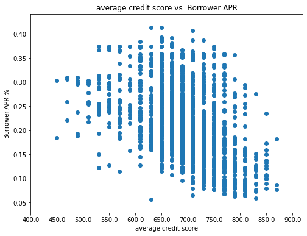

```python
samples = np.random.choice(loan_copy.shape[0], 2000, replace = False)
loan_sample = loan_copy.loc[samples,:]
plt.figure(figsize = [8, 6])
plt.scatter(data = loan_sample, x = 'average_credit_score', y = 'BorrowerAPR')

binsize = 50
x_ticks = np.arange(400,loan_sample['average_credit_score'].max()+binsize, binsize)
plt.xlim(400,loan_sample['average_credit_score'].max()+binsize)
x_tick_name = map(str, x_ticks)
plt.xticks(x_ticks,x_tick_name )
plt.xlabel('average credit score')

plt.title('average credit score vs. Borrower APR')

y_ticks = [0.05,0.10,0.15,0.20,0.25,0.30,0.35,0.40,0.45,0.50]
plt.ylabel('Borrower APR %')

plt.show()
```

### Numerical vs. Numerical

#### Pair 3: Loan Original Amount vs. Borrower APR

**Observations**:  
Some loan amount saw high density -- 4K, 15K, and 10K especially.  
Within each amount, we witnessed high frequency APR at:

- 36% for 4K loans
- 31% for 10K loans
- 20% for 15K loans

As the loan size increases, the high density APR tends to decrease, which makes sense because those customers might have better credit ratings and Prosper will be more likely to lend more money to borrowers it can trust.

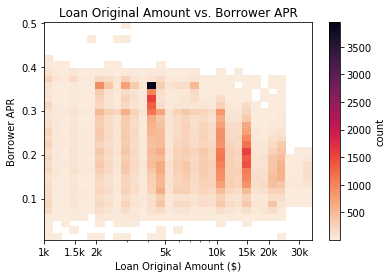

```python
log_binsize = 0.05
bins_loa = 10 ** np.arange(3, np.log10(loan_copy['LoanOriginalAmount'].max())+log_binsize, log_binsize)

bin_y = np.arange(0.006,0.512, 0.015)
plt.hist2d(data = loan_copy, x = 'LoanOriginalAmount', y = 'BorrowerAPR', cmin = 0.5,
          cmap = 'rocket_r', bins = [bins_loa, bin_y])
plt.xscale('log')
x_ticks = [1000, 1500, 2000,5000, 10000, 15000,20000, 30000]
x_ticks_names = ['1k','1.5k', '2k', '5k', '10k','15k', '20k','30k']
plt.xticks(x_ticks, x_ticks_names)
plt.colorbar(label = 'count')
plt.xlabel('Loan Original Amount ($)')
plt.ylabel('Borrower APR')
plt.title('Loan Original Amount vs. Borrower APR')
```

```python
a = loan_copy.groupby(['LoanOriginalAmount','BorrowerAPR']).count()['ListingKey'].reset_index()
```

```python
a.query('LoanOriginalAmount == 10000').ListingKey.max()
```

```
112
```

```python
a.query('ListingKey == 112')
```

|  | LoanOriginalAmount | BorrowerAPR | ListingKey |
| --- | --- | --- | --- |
| 24607 | 10000 | 0.30532 | 112 |

```python
loan_copy.AvailableBankcardCredit.describe()
```

```
count    106393.000000
mean      11210.225447
std       19818.361309
min           0.000000
25%         880.000000
50%        4100.000000
75%       13180.000000
max      646285.000000
Name: AvailableBankcardCredit, dtype: float64
```

### Numerical vs. Numerical

#### Pair 4: average bank card credit vs. Borrower APR

**Observations**:  
We also witnessed a negative relationship between borrower APR and available bank card credit (The total available credit via bank card at the time the credit profile was pulled). This makes perfect sense because usually people who have a higher bank card credit balance also have better credit ratings. We already know that better credit ratings indicate lower APR based on earlier analyses.

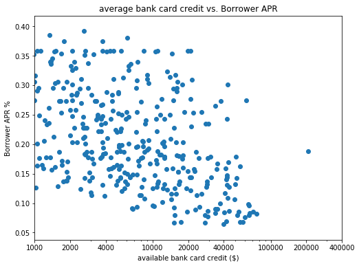

```python
samples = np.random.choice(loan_copy.shape[0], 500, replace = False)
loan_sample = loan_copy.loc[samples,:]
plt.figure(figsize = [8, 6])
plt.scatter(data = loan_sample, x = 'AvailableBankcardCredit', y = 'BorrowerAPR')
plt.xscale('log')

binsize = 0.025
bins_x = 10 ** np.arange(3, np.log10(loan_sample['AvailableBankcardCredit'].max())+binsize, binsize)
plt.xlim(1000,loan_sample['AvailableBankcardCredit'].max()+binsize)
xticks = [1000, 2000, 4000, 10000, 20000, 40000,100000,200000,400000]
x_tick_name = map(str, xticks)
plt.xticks(xticks,x_tick_name )
plt.xlabel('available bank card credit ($)')
plt.title('average bank card credit vs. Borrower APR')

y_ticks = [0.05,0.10,0.15,0.20,0.25,0.30,0.35,0.40,0.45,0.50]
plt.ylabel('Borrower APR %')

plt.show()
```

**Observations**:  
There are some negative relationships between BorrowerAPR and couple categorical variables like Credit Grade and Prosper Rating. In other word, when Credit Grade or Prosper Rating gets better, Borrower APR tends to decrease.

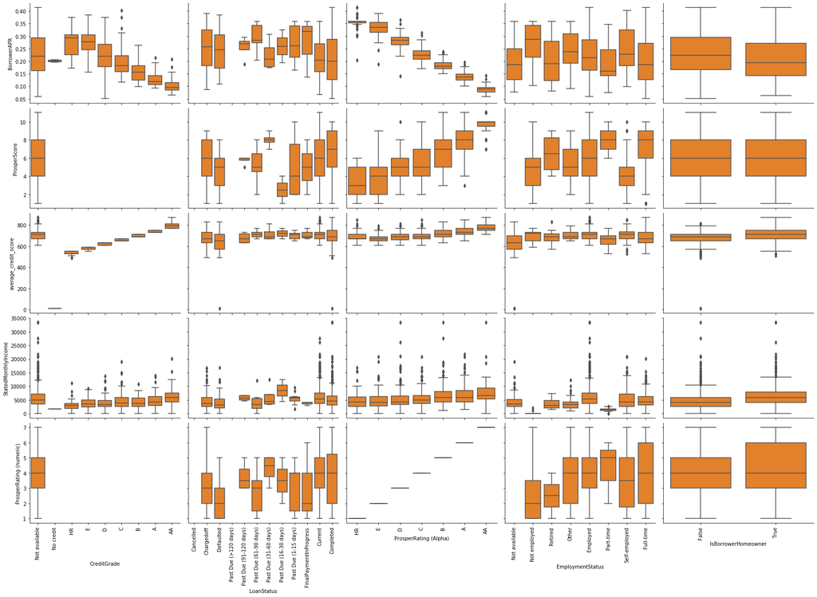

```python
# After plotting out the relationships among numeric variables,
#now we are going to plot a matrix of numeric features against categorical features.
samples = np.random.choice(loan_copy.shape[0], 2000, replace = False)
loan_sample = loan_copy.loc[samples,:]
def boxgrid(x, y, **kwargs):
    default_color = sb.color_palette()[1]
    sb.boxplot(x, y, color = default_color)
    plt.xticks(rotation = 90)
plt.figure(figsize = [10,10])
categoric_vars = ['CreditGrade',
                  'LoanStatus',
                  'ProsperRating (Alpha)',
                  'EmploymentStatus',
                'IsBorrowerHomeowner'
                 ]

g = sb.PairGrid(data = loan_sample, y_vars = ['BorrowerAPR', 'ProsperScore','average_credit_score', 'StatedMonthlyIncome','ProsperRating (numeric)'], x_vars = categoric_vars, size = 3, aspect =1.5)
g.map(boxgrid)
plt.show()
```

### Numerical vs. Categorical

#### Pair 1: Borrower APR vs. Credit Grade or Prosper Rating (Alpha)

**Observations**:  
It appears that the increase in ProsperRating (Alpha) or Credit Grade was usually accompanied by a decrease in Borrower APR. In other word, better Ratings have lower Borrower APRs. To put it into perspective, borrowers with AA prosper ratings could expect an APR that will likely fall into the 8-10% range, whereas borrowers with bad ratings (HR) could expect their APRs to go as high as ~35%!

By comparing the two graphs, we tend to see more outliers in the case of Credit Grade vs. Prosper Rating. To put it into perspective, if your Credit Grade is AA, your Borrower APR could range from 1.6% to 33% (very wide range). In contrast, if your Prosper Rating is AA, your Borrower APR would be 4.6%-21%, which is a slightly narrower range.

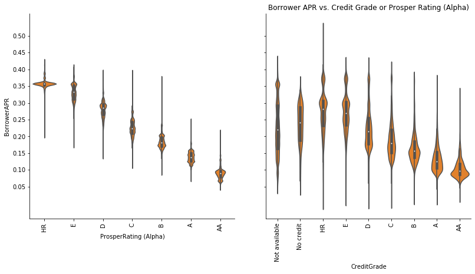

```python
# Next I will use violin plot to explore the relationship between Borrower APR and Credit Grade or Proper Rating (Alpha)

def boxgrid(x,y,**kwargs):
    default_color = sb.color_palette()[1]
    sb.violinplot(x, y, color = default_color)
    y_ticks = [0.05,0.10,0.15,0.20,0.25,0.30,0.35,0.40,0.45,0.50]
    y_ticks_names = ['0.05','0.10','0.15','0.20','0.25','0.30','0.35','0.40','0.45','0.50']
    plt.yticks(y_ticks, y_ticks_names)
    plt.xticks(rotation = 90)
    plt.ylabel('Borrower APR')

g = sb.PairGrid(data = loan_copy, y_vars = 'BorrowerAPR', x_vars = ['ProsperRating (Alpha)','CreditGrade'])
plt.title('Borrower APR vs. Credit Grade or Prosper Rating (Alpha)')
g.fig.set_size_inches(12,6)
g.map(boxgrid)
plt.show()
```

### Numerical vs. Categorical

#### Pair 2: Borrower APR vs. EmploymentStatus

**Observations:**  
Not surprisingly, people who are not employed would receive the highest APR at ~28% vs. employed borrowers' 22%. Interesting to find out that part-time workers' mean APR was at the same level as full-time workers!

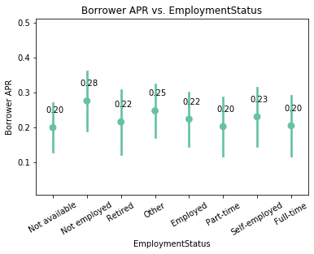

```python
sb.pointplot(data = loan_copy, x = 'EmploymentStatus', y = 'BorrowerAPR',
          color = base_color, ci = 'sd', linestyles = '')


plt.xticks(rotation = 30)
plt.ylabel('Borrower APR')
plt.ylim((0.006,0.512))
mean_calc = loan_copy.groupby('EmploymentStatus')['BorrowerAPR'].mean()
type_counts = loan_copy['EmploymentStatus'].value_counts()
plt.title('Borrower APR vs. EmploymentStatus')
for i in range(type_counts.shape[0]):
    mean_VClass = mean_calc[i]
    mean_string = '{:0.2f}'.format(mean_VClass)
    plt.text(i-0.2, mean_VClass+0.05, mean_string, va = 'center')
```

### Numerical vs. Categorical

#### Pair 3: Borrower APR vs. ProsperRating (Alpha)

**Observations:**  
Consistent with our findings about the relationship between ProsperRating (numeric) and BorrowerAPR, we are seeing that when Prosper Rating (Alpha) improves, Borrower APR tends to decrease.

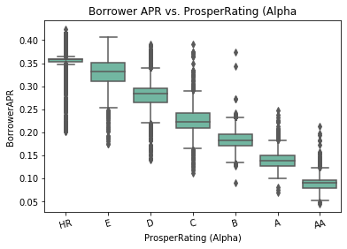

```python
sb.boxplot(data = loan_copy, x = 'ProsperRating (Alpha)', y = 'BorrowerAPR',
              color = base_color)
plt.xticks(rotation = 15)
plt.title('Borrower APR vs. ProsperRating (Alpha')
```

## Talk about some of the relationships you observed in this part of the investigation. How did the feature(s) of interest vary with other features in the dataset?

Our area of interest is to find out the factors that go into getting the lowest Borrower APR possible.

**Borrower APR and Prosper Rating have a strong negative correlation!**:

- Borrower APR had a high correlation with Prosper Rating. When Prosper Rating increases, we tend to see a lower Borrower APR.

**That's good to know but individual borrowers do not have visibility into Prosper Rating**:

- Prosper Rating is an internal rating that Prosper assigns to loan applicants and it is challenging to find out their own Prosper Rating if the borrowers are new to applying for loans. Are there any factors that customers have easy access to that may have a good correlation with the APR they could expect to receive from Prosper? The answer is yes -- credit score and available bank card credit! For credit score, this analysis takes the average of the CreditScoreRangeLower and CreditScoreRangeUpper variables and created a new variable called average_credit_score, which saw a moderate -0.43 correlation with Borrower's APR. On the other hand, available bank card credit and Borrower APR had a -0.349r.

**For individual borrowers, it might be a good idea to monitor**:

- **credit scores**: a lot of credit card apps allow customers to check their FICO scores. The higher the credit score, the lower the APR.
- **available bank card credit**: borrowers can easily calculate this by opening up their credit card apps. The higher the available bank card credit, the lower the APR.

**Employment status-wise, it certainly helps to have a full time job (at least a part-time one)**, having a job means that the borrower's APR could go down from 0.28 to 0.20!

**It also helps if the borrower is a home owner!** We are seeing a lower median borrower APR from home owners vs. non-home owners.

## Did you observe any interesting relationships between the other features (not the main features of interest?

- Prosper rating and average credit score have a moderate positive correlation of 0.549. The higher the credit score, the higher the prosper rating.
- Loan original amount also saw a moderate positive correlation with Prosper rating at 0.429. The higher the prosper rating , the more loan original amount we tend to see.

## Multivariate Exploration

As a next step, I will focus on exploring how categorical measures play into the relationship between Prosper Rating (Alpha) and Borrower APR. Categorical measures I would like to investigate further here included:

- LoanStatus
- Term
- IsBorrowerHomeowner
- EmploymentStatus

### Part 1: LoanStatus --> Prosper Rating (Alpha) vs Borrower APR

```python
# I am going to focus on three loan status -- Current / Paid, Defaulted, and Past Due only.
loan_copy_sub = loan_copy.loc[loan_copy['LoanStatus'].isin([
    'Current',
    'Completed',
    'Defaulted',
    'Past Due (1-15 days)',
    'Past Due (31-60 days)',
'Past Due (61-90 days)',
'Past Due (91-120 days)',
'Past Due (16-30 days)',
'Past Due (>120 days)'
])]
```

```python
# next I will consolidate the six past due status into one status: Past Due.
# Convert Current or Completed into one status: Healthy
loan_status_abbrev = {
       'Current':'Healthy: Current or Completed',
    'Completed':'Healthy: Current or Completed',
    'Defaulted':'Defaulted',
    'Past Due (1-15 days)':'Past Due',
    'Past Due (31-60 days)':'Past Due',
'Past Due (61-90 days)':'Past Due',
'Past Due (91-120 days)':'Past Due',
'Past Due (16-30 days)':'Past Due',
'Past Due (>120 days)':'Past Due'
    }


# Function to apply
def abbreviate_source(loan_copy):
    if loan_copy['LoanStatus'] in loan_status_abbrev.keys():
        abbrev = loan_status_abbrev[loan_copy['LoanStatus']]
        return abbrev
    else:
        return loan_copy['LoanStatus']

loan_copy['LoanStatus'] = loan_copy.apply(abbreviate_source, axis=1)
```

```python
# Check to see if the magic was done.
loan_copy.LoanStatus.value_counts()
```

```
Healthy: Current or Completed    94650
Chargedoff                       11992
Defaulted                         5018
Past Due                          2067
FinalPaymentInProgress             205
Cancelled                            5
Name: LoanStatus, dtype: int64
```

```python
loan_copy_sub = loan_copy.loc[loan_copy['LoanStatus'].isin([
'Healthy: Current or Completed',
    'Defaulted',
    'Past Due'
])]
```

```python
loan_copy_sub.LoanStatus.value_counts()
```

```
Healthy: Current or Completed    94650
Defaulted                         5018
Past Due                          2067
Name: LoanStatus, dtype: int64
```

**Observations**:  
We can see the relationship of Borrower APR and Prosper Rating (Alpha) to varying loan status. For all Prosper Ratings except for "A", Defaulted loans usually have a higher Borrower APR compared to Healthy or past due ones.

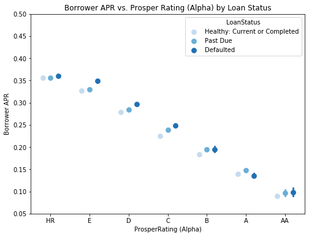

```python
fig = plt.figure(figsize = [8,6])
ax = sb.pointplot(data = loan_copy_sub, x = 'ProsperRating (Alpha)', y = 'BorrowerAPR', hue = 'LoanStatus',
           palette = 'Blues', linestyles = '', dodge = 0.4)
plt.title('Borrower APR vs. Prosper Rating (Alpha) by Loan Status')
plt.ylabel('Borrower APR')
plt.yticks([0.05,0.10,0.15,0.20,0.25,0.30,0.35,0.40,0.45,0.50], ['0.05','0.10','0.15','0.20','0.25','0.30','0.35','0.40','0.45','0.50'])
ax.set_yticklabels([],minor = True)
plt.show();
```

### Part 2: Term --> Prosper Rating (Alpha) vs Borrower APR

```python
loan_copy.Term.value_counts()
```

```
36    87778
60    24545
12     1614
Name: Term, dtype: int64
```

**Observations**  
The graph displays that for high-rating borrowers (A or AA), 60-month loans usually have a higher Borrower APR vs. 12-month loans. This makes sense because the more money you want to borrow, the riskier the transaction is for Prosper and the higher your APR is likely to be.

For B-C borrowers, we did not see Borrower APR varies by loan terms.

When it comes to lower credit rating borrowers (E-D), 12-month loans actually have higher APRs than 60-month ones. This is probably due to the fact that Prosper knows that they are not very likely to pay the full amount back, so giving thse borrowers more time (60 months instead of 12 months) might allow them to repay more debt amount.

Interestingly, for HR customers, only 36 month loans were seen in this dataset.

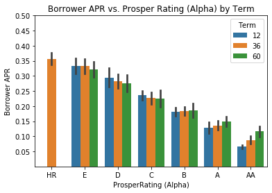

```python
#base_color = sb.color_palette('Set2')[0:3]
sb.barplot(data = loan_copy, x = 'ProsperRating (Alpha)', y = 'BorrowerAPR', hue = 'Term',
           ci = 'sd')
plt.title('Borrower APR vs. Prosper Rating (Alpha) by Term')
plt.ylabel('Borrower APR')
plt.yticks([0.05,0.10,0.15,0.20,0.25,0.30,0.35,0.40,0.45,0.50], ['0.05','0.10','0.15','0.20','0.25','0.30','0.35','0.40','0.45','0.50'])
ax.set_yticklabels([],minor = True)
plt.show();
```

### Part 3: IsBorrowerHomeowner --> Prosper Rating (Alpha) vs Borrower APR

**Observations**: Whether the borrower is a homeowner or not does not make a difference in APR under each Prosper Rating group.

**Wait but I thought you said "It also helps if the borrower is a home owner!" in the previous section?** Yes I did! In the previous section, I ran a boxplot to plot out the median APR of homeowners vs. non-homeowners, but did not take into account that maybe the homeowner group just houses more high credit rating borrowers whereas the non-homeowners might consist of low credit rating borrowers. Let's further investigate to see if that's the case!

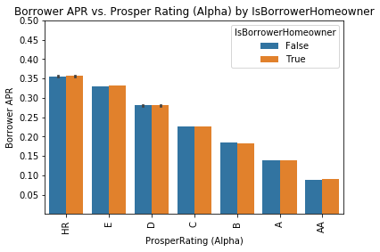

```python
sb.barplot(data = loan_copy,x='ProsperRating (Alpha)', y='BorrowerAPR',hue = 'IsBorrowerHomeowner');
plt.xticks(rotation = 90)
plt.title('Borrower APR vs. Prosper Rating (Alpha) by IsBorrowerHomeowner')
plt.ylabel('Borrower APR')
plt.yticks([0.05,0.10,0.15,0.20,0.25,0.30,0.35,0.40,0.45,0.50], ['0.05','0.10','0.15','0.20','0.25','0.30','0.35','0.40','0.45','0.50'])
ax.set_yticklabels([],minor = True)
plt.show();
```

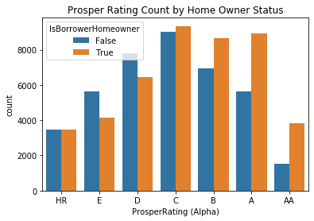

```python
sb.countplot(data = loan_copy, x = 'ProsperRating (Alpha)', hue = 'IsBorrowerHomeowner')
plt.title('Prosper Rating Count by Home Owner Status')
```

As expected, home owners (orange bar) made up for the majority of borrowers with great ratings (B-AA). In comparison, non-home owners made up for the majority for E and D borrowers.

### Part 4: EmploymentStatus --> Prosper Rating (Alpha) vs Borrower APR

**Observations**:

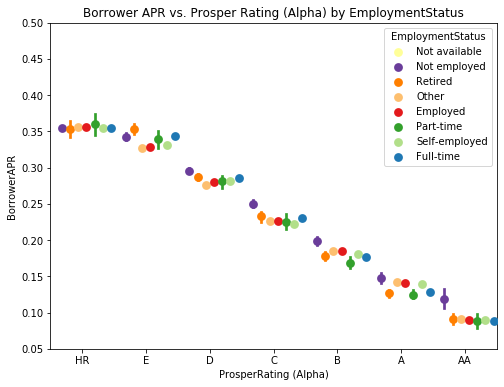

```python
## Example of nominal data ##
fig = plt.figure(figsize = [8,6])
ax = sb.pointplot(data = loan_copy, x = 'ProsperRating (Alpha)', y = 'BorrowerAPR', hue = 'EmploymentStatus',
           palette = 'Paired_r', linestyles = '', dodge = 0.9)
plt.title('Borrower APR vs. Prosper Rating (Alpha) by EmploymentStatus')
plt.ylabel('BorrowerAPR')
#plt.yscale('log')
plt.yticks([0.05,0.10,0.15,0.20,0.25,0.30,0.35,0.40,0.45,0.50], ['0.05','0.10','0.15','0.20','0.25','0.30','0.35','0.40','0.45','0.50'])
#plt.yticks([2e3, 4e3, 6e3, 1e4], ['2k', '4k', '6k', '10k'])
ax.set_yticklabels([],minor = True)
plt.show();
#base_color = sb.color_palette('Set2')[3]
#legend_obj = [] # create an empty list
#sizes = [200, 350, 500]
#for s in sizes:
#    legend_obj.append(plt.scatter([],[], s = s/2, color = base_color))
#plt.legend(legend_obj, sizes, title = 'CO2')
```

## That concludes our exploration of how categorical measures play into the relationship between Prosper Rating (Alpha) and Borrower APR. Next, I will take a stab at some other multivariate analyses.

### Employment Status --> average credit score vs Borrower APR

```python
def hist2dgrid(x, y, **kwargs):
    palette = kwargs.pop('color')
    binsize_x = 25
    bins_x = np.arange(350, loan_copy['average_credit_score'].max()+binsize_x, binsize_x)
    binsize_y = 0.005
    bins_y = np.arange(0.006, loan_copy['BorrowerAPR'].max()+binsize_y, binsize_y)
    plt.hist2d(x, y, bins = [bins_x, bins_y], cmap = palette, cmin = 0.5)
    x_ticks = np.arange(350, 900+50, 50)
    x_ticks_names = ['350','400','450','500','550','600','650','700','750','800','850','900']
    y_ticks = [0.05,0.10,0.15,0.20,0.25,0.30,0.35,0.40,0.45,0.50]
    y_ticks_name = ['0.05','0.10','0.15','0.20','0.25','0.30','0.35','0.40','0.45','0.50']
    #    y_ticks_names = y_ticks.astype('str')
    plt.xticks(x_ticks,x_ticks_names )
    plt.yticks(y_ticks,y_ticks_name)
```

**Observations**:  
In each of the faceted heat maps, you can see the relationship of credit score and Borrower APR by different employment status. For Employed, Part-time, Full-time, and Retired, we can see most of the dark color points falling in a downward trending line, hinting an apparent relationship of higher credit score leading to a lower borrower APR; however, for self-employed, not employed, not available, and other, we saw more ambiguous relationships.

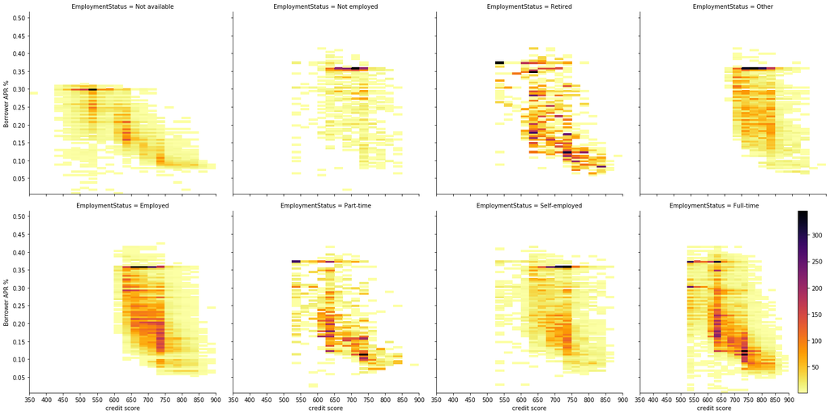

```python
# create faceted heat maps on levels of the color variable

g = sb.FacetGrid(data = loan_copy, col = 'EmploymentStatus', col_wrap = 4, size = 5,
                 xlim = [350, 900], ylim = [0.006,0.512])
g.map(hist2dgrid, 'average_credit_score', 'BorrowerAPR', color = 'inferno_r')

g.set_xlabels('credit score')
g.set_ylabels('Borrower APR %')
plt.colorbar()
plt.show()
```

### What's next? I would like to create a new dataset to find out which occupations are more likely to have unhealthy loan status and if the relationships that we discovered previously still hold true at the Occupation level.

As a next step of the analysis, I would like to transform the original dataset and create a new dataset that contains each Occupation's mean monthly income (StatedMonthlyIncome variable), mean loan size (LoanOriginalAmount), mean Borrower APR, and bad debt percentage*.

*Bad debt percentage was calculated by deriving the possibility of any loan status except for Current or Completed.

```python
job_loanstatus = loan_copy_sub.groupby(['Occupation', 'LoanStatus']).agg({'LoanStatus':'count'})
jl_pcts = job_loanstatus.groupby('Occupation', as_index=False).apply(lambda x: x / float(x.sum()))
```

```python
jl_pcts.columns = ['GoodDebt']
```

```python
jl_pcts.reset_index()
```

|  | Occupation | LoanStatus | GoodDebt |
| --- | --- | --- | --- |
| 0 | Accountant/CPA | Defaulted | 0.031240 |
| 1 | Accountant/CPA | Healthy: Current or Completed | 0.950286 |
| 2 | Accountant/CPA | Past Due | 0.018475 |
| 3 | Administrative Assistant | Defaulted | 0.067018 |
| 4 | Administrative Assistant | Healthy: Current or Completed | 0.908470 |
| 5 | Administrative Assistant | Past Due | 0.024511 |
| 6 | Analyst | Defaulted | 0.029682 |
| 7 | Analyst | Healthy: Current or Completed | 0.952508 |
| 8 | Analyst | Past Due | 0.017809 |
| 9 | Architect | Defaulted | 0.036269 |
| 10 | Architect | Healthy: Current or Completed | 0.953368 |
| 11 | Architect | Past Due | 0.010363 |
| 12 | Attorney | Defaulted | 0.012884 |
| 13 | Attorney | Healthy: Current or Completed | 0.978196 |
| 14 | Attorney | Past Due | 0.008920 |
| 15 | Biologist | Healthy: Current or Completed | 0.973214 |
| 16 | Biologist | Past Due | 0.026786 |
| 17 | Bus Driver | Defaulted | 0.047101 |
| 18 | Bus Driver | Healthy: Current or Completed | 0.923913 |
| 19 | Bus Driver | Past Due | 0.028986 |
| 20 | Car Dealer | Defaulted | 0.054878 |
| 21 | Car Dealer | Healthy: Current or Completed | 0.896341 |
| 22 | Car Dealer | Past Due | 0.048780 |
| 23 | Chemist | Defaulted | 0.031008 |
| 24 | Chemist | Healthy: Current or Completed | 0.961240 |
| 25 | Chemist | Past Due | 0.007752 |
| 26 | Civil Service | Defaulted | 0.034325 |
| 27 | Civil Service | Healthy: Current or Completed | 0.946606 |
| 28 | Civil Service | Past Due | 0.019069 |
| 29 | Clergy | Defaulted | 0.027322 |

[output cut: 165 more lines]

```python
jl_pcts = jl_pcts.query('LoanStatus == "Healthy: Current or Completed"')
```

```python
jl_pcts.sample(3)
```

| Occupation | LoanStatus | GoodDebt |
| --- | --- | --- |
| Religious | Healthy: Current or Completed | 0.953271 |
| Clerical | Healthy: Current or Completed | 0.876289 |
| Student - College Freshman | Healthy: Current or Completed | 0.866667 |

```python
job_income = loan_copy_sub.groupby(['Occupation'])['StatedMonthlyIncome','LoanOriginalAmount','BorrowerAPR'].mean().reset_index()
```

```python
df_join = pd.merge(job_income,
                     jl_pcts,
                     on ='Occupation',
                     how ='left')
#df_join['reg'] = df_join.reg.fillna(0)
#df_join['sub_region'] = df_join.sub_region.fillna('Not identified')
#df_join['Date']= pd.to_datetime(df_join['Date'])
#df_final = df_join.groupby(['Date','sub_region'])['reg'].sum().reset_index()
```

```python
df_join.sample(10)
```

|  | Occupation | StatedMonthlyIncome | LoanOriginalAmount | BorrowerAPR | GoodDebt |
| --- | --- | --- | --- | --- | --- |
| 61 | Tradesman - Carpenter | 4486.084984 | 7407.920792 | 0.218539 | 0.950495 |
| 35 | Other | 4810.513888 | 8007.447135 | 0.220285 | 0.925252 |
| 10 | Clergy | 4869.743625 | 7958.792350 | 0.218306 | 0.956284 |
| 43 | Psychologist | 6290.746454 | 8870.106383 | 0.201518 | 0.964539 |
| 0 | Accountant/CPA | 6463.849681 | 9412.137051 | 0.205698 | 0.950286 |
| 14 | Dentist | 10646.420398 | 11018.656716 | 0.205423 | 0.940299 |
| 25 | Investor | 9801.592105 | 9173.589474 | 0.216478 | 0.963158 |
| 20 | Fireman | 6234.481894 | 9553.505236 | 0.210021 | 0.929319 |
| 16 | Engineer - Chemical | 8673.513221 | 11039.629808 | 0.188299 | 0.961538 |
| 27 | Laborer | 3514.461242 | 6770.306392 | 0.234367 | 0.917708 |

```python
df_join['BadDebtPct'] = 1 - df_join['GoodDebt']
```

```python
df_join = df_join[['Occupation', 'StatedMonthlyIncome', 'BadDebtPct','BorrowerAPR','LoanOriginalAmount']]
```

```python
df_join.sample(10)
```

|  | Occupation | StatedMonthlyIncome | BadDebtPct | BorrowerAPR | LoanOriginalAmount |
| --- | --- | --- | --- | --- | --- |
| 15 | Doctor | 15018.323297 | 0.036559 | 0.182432 | 13174.260215 |
| 43 | Psychologist | 6290.746454 | 0.035461 | 0.201518 | 8870.106383 |
| 21 | Flight Attendant | 4270.293239 | 0.075472 | 0.227066 | 7856.226415 |
| 11 | Clerical | 3171.268808 | 0.123711 | 0.233274 | 6218.196613 |
| 46 | Retail Management | 4997.184205 | 0.070873 | 0.221607 | 8439.355229 |
| 32 | Nurse (LPN) | 4056.868056 | 0.053241 | 0.230480 | 8175.289352 |
| 28 | Landscaping | 3997.981971 | 0.024038 | 0.220873 | 7205.038462 |
| 33 | Nurse (RN) | 6805.332042 | 0.044339 | 0.208004 | 10832.835988 |
| 13 | Construction | 5705.373039 | 0.081238 | 0.213541 | 9525.764668 |
| 31 | Military Officer | 7619.202998 | 0.024390 | 0.197226 | 9220.743902 |

### Part 1: which occupations are more likely to have unhealthy loan status?

**Observations**:

- Top three occupations with the highest bad debt rate: all Students!
- Top three occupations with the lowest bad debt rate: Attorney, Landscaping, and Military Officer.

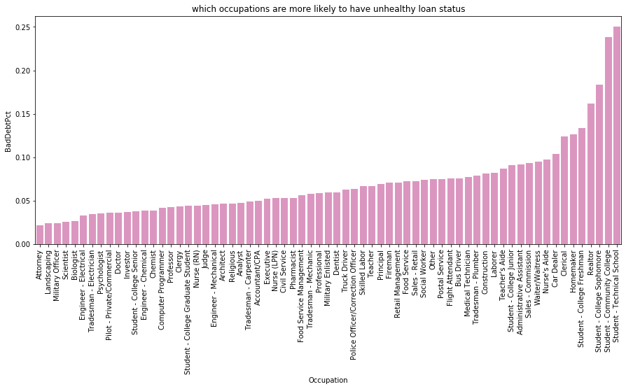

```python
base_color = sb.color_palette('Set2')[3]
plt.figure(figsize = [15,6])
sb.barplot(data = df_join, x = 'Occupation', y = 'BadDebtPct',order=df_join.sort_values('BadDebtPct').Occupation, color = base_color)
plt.xticks(rotation = 90)
plt.title('which occupations are more likely to have unhealthy loan status')
```

### Part 2: Is there a relationship between an occupation's income and bad debt percentage? If yes, is Prosper factoring in the potential possibility of bad debt and charging these borrowers higher APRs?

**Observations**: There is a clear negative relationship between bad debt percentage and stated monthly income. Prosper is also savvy enough to charge these likely-to-default occupations like students higher APRs (see the dark points on the top left corner of the graph) and charge likely-to-repay occupations lower APRs (see the bright spots on the lower right corner of the graph).

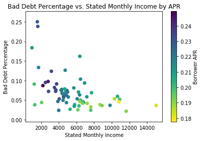

```python
plt.scatter(data = df_join, x = 'StatedMonthlyIncome', y = 'BadDebtPct', c = 'BorrowerAPR',
            cmap = 'viridis_r')
plt.colorbar(label = 'Borrower APR')
plt.xlabel('Stated Monthly Income')
plt.ylabel('Bad Debt Percentage')
plt.title('Bad Debt Percentage vs. Stated Monthly Income by APR')
```

### Part 3: Which factors go into the bad debt percentage?

**Observations**:  
The graph reveals the following relationships:

- The higher the montly income of an occupation, the lower the bad debt percentage is likely to be.
- The higher the APR, the higher the bad debt percentage.
- The higher the loan original amount, the lower the bad debt percentage.

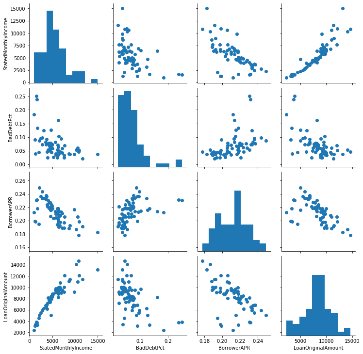

```python
# We are going to create a plot matrix to answer this question.
g = sb.PairGrid(data = df_join, vars = ['StatedMonthlyIncome','BadDebtPct','BorrowerAPR','LoanOriginalAmount'])
g.map_diag(plt.hist)
g.map_offdiag(plt.scatter)
```

## Talk about some of the relationships you observed in this part of the investigation. Were there features that strengthened each other in terms of looking at your feature(s) of interest?¶

**Home owner vs. non-home owners**:

- Home owners tend to see lower APR because home owners made up for the majority of borrowers with great ratings (B-AA). In comparison, non-home owners made up for the majority for E and D borrowers.

**Loan Status**:

- For all Prosper Ratings except for "A", Defaulted loans usually have a higher Borrower APR compared to Healthy or past due ones.

**Loan Terms**:

- For high-rating borrowers (A or AA), 60-month loans usually have a higher Borrower APR vs. 12-month loans. This makes sense because the more money you want to borrow, the riskier the transaction is for Prosper and the higher your APR is likely to be.
- For B-C borrowers, we did not see Borrower APR varies by loan terms.
- When it comes to lower credit rating borrowers (E-D), 12-month loans actually have higher APRs than 60-month ones. This is probably due to the fact that Prosper knows that they are not very likely to pay the full amount back, so giving thse borrowers more time (60 months instead of 12 months) might allow them to repay more debt amount.
- Interestingly, for HR customers, only 36 month loans were seen in this dataset.

**Employment Status**:

**Other findings**:

- For Employed, Part-time, Full-time, and Retired, there was an apparent relationship of higher credit score leading to a lower borrower APR; however, for self-employed, not employed, not available, and other, we saw more ambiguous relationships.

**Findings in the Occupation dataset**:

- There is a clear negative relationship between bad debt percentage and stated monthly income of an occupation. Prosper is also savvy enough to charge these likely-to-default occupations like students higher APRs (see the dark points on the top left corner of the graph) and charge likely-to-repay occupations lower APRs (see the bright spots on the lower right corner of the graph).
- The higher the montly income of an occupation, the lower the bad debt percentage is likely to be.
- The higher the APR, the higher the bad debt percentage.
- The higher the loan original amount, the lower the bad debt percentage.

## Were there any interesting or surprising interactions between features?

Whether the borrower is a homeowner or not does not make a difference in APR under each Prosper Rating group.

In the Bivariate section, I mentioned that if the borrower is a home owner, the median APR is lower than non-home owner, but did not take into account that maybe the homeowner group just houses more high credit rating borrowers whereas the non-homeowners might consist of low credit rating borrowers.